# Visualising the History of openSenseMap.org

Norwin Roosen

2023-03-08

> This vignette serves as an example on data wrangling & visualization with `opensensmapr`, `dplyr` and `ggplot2`.

```r
# required packages:
library(opensensmapr) # data download
library(dplyr)        # data wrangling
library(ggplot2)      # plotting
library(lubridate)    # date arithmetic
library(zoo)          # rollmean()
```

While `opensensmapr` provides extensive methods of filtering boxes by attributes on the server, we do the filtering within R to save time and gain flexibility. So the first step is to retrieve *all the boxes*:

```r
# if you want to see results for a specific subset of boxes,
# just specify a filter such as grouptag='ifgi' here

# boxes = osem_boxes(cache = '.')
boxes = readRDS('boxes_precomputed.rds')  # read precomputed file to save resources
```

# Plot count of boxes by time

By looking at the `createdAt` attribute of each box we know the exact time a box was registered. With this approach we have no information about boxes that were deleted in the meantime, but that’s okay for now.

## …and exposure

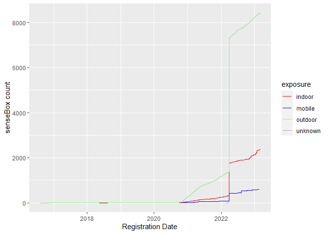

```r
exposure_counts = boxes %>%
  group_by(exposure) %>%
  mutate(count = row_number(createdAt))

exposure_colors = c(indoor = 'red', outdoor = 'lightgreen', mobile = 'blue', unknown = 'darkgrey')
ggplot(exposure_counts, aes(x = createdAt, y = count, colour = exposure)) +
  geom_line() +
  scale_colour_manual(values = exposure_colors) +
  xlab('Registration Date') + ylab('senseBox count')
```

Let’s have a quick summary:

```r
exposure_counts %>%
  summarise(
    oldest = min(createdAt),
    newest = max(createdAt),
    count = max(count)
  ) %>%
  arrange(desc(count))
```

| exposure | oldest | newest | count |
| --- | --- | --- | --- |
| outdoor | 2016-08-09 19:34:42 | 2023-02-28 09:47:17 | 8417 |
| indoor | 2018-05-10 20:14:44 | 2023-02-27 09:53:33 | 2364 |
| mobile | 2020-10-24 14:39:30 | 2023-02-20 16:32:48 | 590 |
| unknown | 2022-03-01 07:04:31 | 2022-03-30 11:25:43 | 19 |

## …and grouptag

We can try to find out where the increases in growth came from, by analysing the box count by grouptag.

Caveats: Only a small subset of boxes has a grouptag, and we should assume that these groups are actually bigger. Also, we can see that grouptag naming is inconsistent (`Luftdaten`, `luftdaten.info`, …)

[figure not shown]

```r
grouptag_counts = boxes %>%
  group_by(grouptag) %>%
  # only include grouptags with 8 or more members
  filter(length(grouptag) >= 8 & !is.na(grouptag)) %>%
  mutate(count = row_number(createdAt))

# helper for sorting the grouptags by boxcount
sortLvls = function(oldFactor, ascending = TRUE) {
  lvls = table(oldFactor) %>% sort(., decreasing = !ascending) %>% names()
  factor(oldFactor, levels = lvls)
}
grouptag_counts$grouptag = sortLvls(grouptag_counts$grouptag, ascending = FALSE)

ggplot(grouptag_counts, aes(x = createdAt, y = count, colour = grouptag)) +
  geom_line(aes(group = grouptag)) +
  xlab('Registration Date') + ylab('senseBox count')
```

```r
grouptag_counts %>%
  summarise(
    oldest = min(createdAt),
    newest = max(createdAt),
    count = max(count)
  ) %>%
  arrange(desc(count))
```

| grouptag | oldest | newest | count |
| --- | --- | --- | --- |
| edu | 2022-03-30 11:25:43 | 2023-02-28 09:47:17 | 431 |
| Save Dnipro | 2022-03-30 11:25:43 | 2022-03-30 11:25:43 | 354 |
| Luftdaten | 2022-03-30 11:25:43 | 2023-01-27 15:22:54 | 244 |
| CS:iDrop | 2023-01-10 10:22:33 | 2023-02-27 09:53:33 | 140 |
| HU Explorers | 2022-03-30 11:25:43 | 2022-12-14 10:11:34 | 124 |
| #stropdeaer | 2022-03-30 11:25:43 | 2022-03-30 11:25:43 | 101 |
| 321heiss | 2022-06-27 14:12:25 | 2022-08-08 10:22:21 | 91 |
| GIZ Clean Air Day Project | 2022-03-30 11:25:43 | 2022-03-30 11:25:43 | 76 |
| Captographies | 2021-05-21 15:24:45 | 2023-01-31 12:11:49 | 62 |
| Futurium | 2022-03-30 11:25:43 | 2022-03-30 11:25:43 | 39 |
| Bad_Hersfeld | 2022-03-30 11:25:43 | 2022-03-30 11:25:43 | 37 |
| TKS Bonn | 2022-03-30 11:25:43 | 2022-03-30 11:25:43 | 36 |
| kerekdomb_ | 2022-03-30 11:25:43 | 2022-03-30 11:25:43 | 34 |
| Mikroprojekt Mitmachklima | 2022-03-30 11:25:43 | 2022-08-23 13:14:11 | 34 |
| Bottrop-Feinstaub | 2022-03-30 11:25:43 | 2022-03-30 11:25:43 | 33 |
| Luchtwachters Delft | 2022-03-30 11:25:43 | 2022-03-30 11:25:43 | 33 |
| Futurium 2021 | 2022-03-30 11:25:43 | 2022-03-30 11:25:43 | 32 |
| Feinstaub | 2022-03-30 11:25:43 | 2022-08-01 16:27:10 | 29 |
| luftdaten.info | 2022-03-30 11:25:43 | 2022-03-30 11:25:43 | 28 |
| ifgi | 2022-03-30 11:25:43 | 2022-03-30 11:25:43 | 26 |
| SUGUCS | 2022-11-30 15:25:32 | 2023-01-23 13:17:54 | 25 |
| cleanairfrome | 2022-03-30 11:25:43 | 2022-05-15 21:13:30 | 24 |
| freshairbromley | 2022-03-30 11:25:43 | 2023-01-31 10:18:57 | 24 |
| WAUW!denberg | 2022-03-30 11:25:43 | 2022-03-30 11:25:43 | 23 |
| Riga | 2022-03-30 11:25:43 | 2022-03-30 11:25:43 | 22 |
| bad_hersfeld | 2022-03-30 11:25:43 | 2022-06-14 09:34:02 | 21 |
| KJR-M | 2022-03-30 11:25:43 | 2022-03-30 11:25:43 | 21 |
| Mikroklima | 2022-03-30 11:25:43 | 2022-09-05 08:38:57 | 21 |
| Smart City MS | 2022-03-30 11:25:43 | 2022-03-30 11:25:43 | 20 |
| SekSeeland | 2022-03-30 11:25:43 | 2022-03-30 11:25:43 | 19 |

[output cut: 58 more lines]

# Plot rate of growth and inactivity per week

First we group the boxes by `createdAt` into bins of one week:

```r
bins = 'week'
mvavg_bins = 6

growth = boxes %>%
  mutate(week = cut(as.Date(createdAt), breaks = bins)) %>%
  group_by(week) %>%
  summarize(count = length(week)) %>%
  mutate(event = 'registered')
```

We can do the same for `updatedAt`, which informs us about the last change to a box, including uploaded measurements. This method of determining inactive boxes is fairly inaccurate and should be considered an approximation, because we have no information about intermediate inactive phases. Also deleted boxes would probably have a big impact here.

```r
inactive = boxes %>%
  # remove boxes that were updated in the last two days,
  # b/c any box becomes inactive at some point by definition of updatedAt
  filter(updatedAt < now() - days(2)) %>%
  mutate(week = cut(as.Date(updatedAt), breaks = bins)) %>%
  group_by(week) %>%
  summarize(count = length(week)) %>%
  mutate(event = 'inactive')
```

Now we can combine both datasets for plotting:

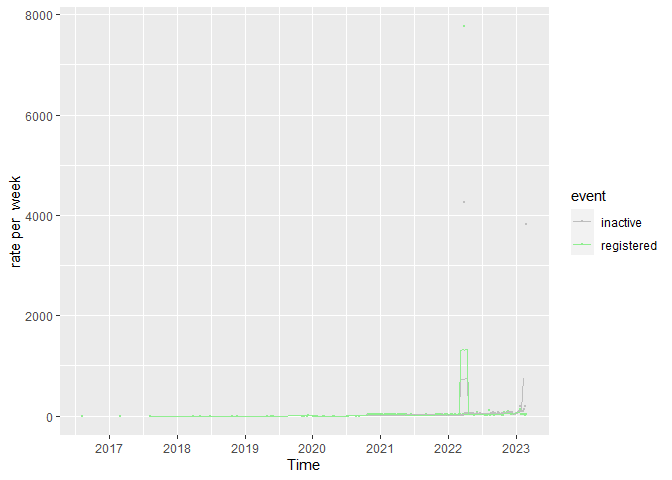

```r
boxes_by_date = bind_rows(growth, inactive) %>% group_by(event)

ggplot(boxes_by_date, aes(x = as.Date(week), colour = event)) +
  xlab('Time') + ylab(paste('rate per ', bins)) +
  scale_x_date(date_breaks="years", date_labels="%Y") +
  scale_colour_manual(values = c(registered = 'lightgreen', inactive = 'grey')) +
  geom_point(aes(y = count), size = 0.5) +
  # moving average, make first and last value NA (to ensure identical length of vectors)
  geom_line(aes(y = rollmean(count, mvavg_bins, fill = list(NA, NULL, NA))))
```

# Plot duration of boxes being active

While we are looking at `createdAt` and `updatedAt`, we can also extract the duration of activity of each box, and look at metrics by exposure and grouptag once more:

## …by exposure

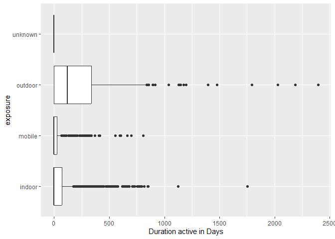

```r
duration = boxes %>%
  group_by(exposure) %>%
  filter(!is.na(updatedAt)) %>%
  mutate(duration = difftime(updatedAt, createdAt, units='days'))

ggplot(duration, aes(x = exposure, y = duration)) +
  geom_boxplot() +
  coord_flip() + ylab('Duration active in Days')
```

The time of activity averages at only 158 days, though there are boxes with 2394 days of activity, spanning a large chunk of openSenseMap’s existence.

## …by grouptag

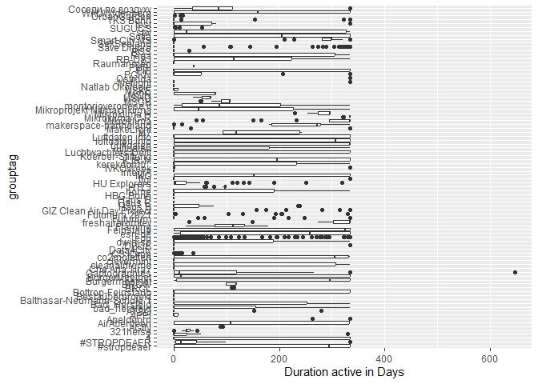

```r
duration = boxes %>%
  group_by(grouptag) %>%
  # only include grouptags with 8 or more members
  filter(length(grouptag) >= 8 & !is.na(grouptag) & !is.na(updatedAt)) %>%
  mutate(duration = difftime(updatedAt, createdAt, units='days'))

ggplot(duration, aes(x = grouptag, y = duration)) +
  geom_boxplot() +
  coord_flip() + ylab('Duration active in Days')
```

```r
duration %>%
  summarize(
    duration_avg = round(mean(duration)),
    duration_min = round(min(duration)),
    duration_max = round(max(duration)),
    oldest_box = round(max(difftime(now(), createdAt, units='days')))
  ) %>%
  arrange(desc(duration_avg))
```

| grouptag | duration_avg | duration_min | duration_max | oldest_box |
| --- | --- | --- | --- | --- |
| Ostroda | 335 days | 335 days | 335 days | 343 days |
| Mikroklima C-R | 332 days | 321 days | 335 days | 343 days |
| Apeldoorn | 331 days | 263 days | 335 days | 343 days |
| freshairbromley | 304 days | 28 days | 335 days | 343 days |
| Mikroklima | 283 days | 42 days | 335 days | 343 days |
| Mikroklima H | 283 days | 229 days | 297 days | 305 days |
| Smart City MS | 272 days | 0 days | 335 days | 343 days |
| Feinstaub | 223 days | 0 days | 335 days | 343 days |
| makerspace-partheland | 217 days | 0 days | 335 days | 343 days |
| co2mofetten | 213 days | 0 days | 334 days | 343 days |
| Luftdaten | 211 days | 0 days | 335 days | 343 days |
| luftdaten.info | 200 days | 0 days | 335 days | 343 days |
| Burgermeetnet | 190 days | 0 days | 335 days | 343 days |
| esri-de | 190 days | 0 days | 335 days | 343 days |
| #stropdeaer | 187 days | 0 days | 335 days | 343 days |
| Sofia | 172 days | 0 days | 335 days | 343 days |
| WAUW!denberg | 168 days | 0 days | 335 days | 343 days |
| KJR-M | 167 days | 0 days | 335 days | 343 days |
| IKG | 163 days | 0 days | 335 days | 343 days |
| AirAberdeen | 155 days | 0 days | 335 days | 343 days |
| M7 | 155 days | 92 days | 243 days | 343 days |
| 1 | 148 days | 0 days | 335 days | 343 days |
| BurgerMeetnet | 141 days | 0 days | 335 days | 343 days |
| Luftdaten.info | 139 days | 0 days | 335 days | 343 days |
| Bottrop-Feinstaub | 133 days | 0 days | 335 days | 343 days |
| cleanairfrome | 130 days | 0 days | 335 days | 343 days |
| montorioveronese.it | 130 days | 0 days | 335 days | 343 days |
| stw | 130 days | 0 days | 335 days | 343 days |
| RB-DSJ | 122 days | 0 days | 335 days | 343 days |
| Mikroprojekt Mitmachklima | 118 days | 0 days | 335 days | 343 days |

[output cut: 58 more lines]

The time of activity averages at only 90 days, though there are boxes with 648 days of activity, spanning a large chunk of openSenseMap’s existence.

## …by year of registration

This is less useful, as older boxes are active for a longer time by definition. If you have an idea how to compensate for that, please send a [Pull Request](https://github.com/sensebox/opensensmapr/pulls)!

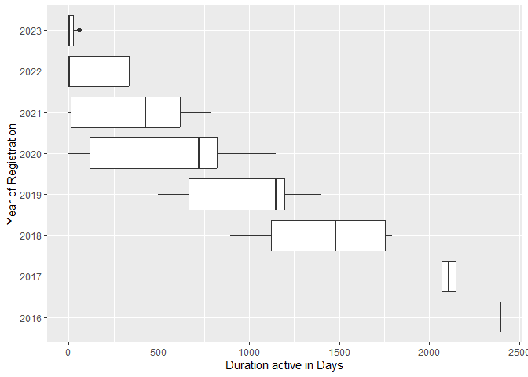

```r
# NOTE: boxes older than 2016 missing due to missing updatedAt in database
duration = boxes %>%
  mutate(year = cut(as.Date(createdAt), breaks = 'year')) %>%
  group_by(year) %>%
  filter(!is.na(updatedAt)) %>%
  mutate(duration = difftime(updatedAt, createdAt, units='days'))

ggplot(duration, aes(x = substr(as.character(year), 0, 4), y = duration)) +
  geom_boxplot() +
  coord_flip() + ylab('Duration active in Days') + xlab('Year of Registration')
```

# More Visualisations

Other visualisations come to mind, and are left as an exercise to the reader. If you implemented some, feel free to add them to this vignette via a [Pull Request](https://github.com/sensebox/opensensmapr/pulls).

- growth by phenomenon
- growth by location -> (interactive) map
- set inactive rate in relation to total box count
- filter timespans with big dips in growth rate, and extrapolate the amount of senseBoxes that could be on the platform today, assuming there were no production issues ;)